[figure not shown]

Previsão de risco de fogo em Vegetação

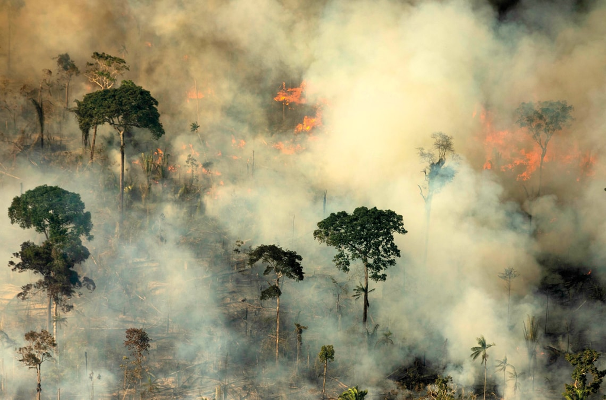

Aplicação de modelos de machine learning para prever o risco de queimadas e de incêndios no Brasil

Análise Exploratória de Dados sobre Queimadas

Experimento, em ciência de dados, para prever o risco de queimadas e de incêndios no Brasil

Entendimento (Insights) sobre o risco de queimadas e de incêndios no Brasil a partir da aplicação de modelos de aprendizado de máquina (Machine Learning)

Experimento de aplicação de modelos de machine learning em base de dados do Programa Queimadas / Inpe para entendimento sobre o risco de fogo no Brasil

## **Sumário**

Introdução

2. Descrição das variáveis
3. Análise Exploratória dos dados

   -Aplicando Imputação em Valores Missing Usando Método PMM (Predictive Mean Matching)

   -Treinamento do modelo de regressão linear n1

   -Treinamento do modelo de regressão linear n2

   -Treinamento do modelo de regressão linear n3

   -Treinamento do modelo de regressão linear n4

## **Introdução**

Em meados de 2021, quando teve início a segunda temporada do [Programa de Mentoria entre Alunos da DSA](https://blog.dsacademy.com.br/programa-de-mentoria-entre-os-alunos-dsa-temporada-2021/), a imprensa destacava a [liderança do Brasil](https://www.climatempo.com.br/noticia/2021/06/02/brasil-lidera-o-ranking-de-queimadas-da-america-do-sul-0141) no ranking de queimadas da América do Sul e a crescente propagação de incêndios em [áreas florestais pelo mundo](https://www.cnnbrasil.com.br/internacional/incendios-florestais-se-espalham-pelo-mundo-e-atingem-novas-regioes/). A escolha do **tema** deste projeto foi reforçada pelo registro, em 2020, se considerada a década que se encerrava, de recorde brasileiro do número de queimadas: [222.797 focos](https://queimadas.dgi.inpe.br/queimadas/portal-static/estatisticas_paises/).

Pesquisa do [MapBiomas](https://mapbiomas-br-site.s3.amazonaws.com/Fact_Sheet.pdf) revela que os incêndios já afetaram - contribuindo para o risco de extinção - 85% das espécies e dos animais na Amazônia. Todos os anos, o Brasil queima uma [área superior](https://mapbiomas.org/a-cada-ano-brasil-queima-area-maior-que-a-inglaterra) à Inglaterra. Além disso, nos últimos 36 anos, 85% da área queimada estavam na Amazônia e no Cerrado. O país ainda está entre as dez primeiras posições no [ranking dos países](https://www.climatewatchdata.org/countries/CHN) com maior emissão de gases do efeito estufa. Face aos alertas de especialistas e ambientalistas acerca dos impactos já verificados no clima e na biodiversidade, **um campo propício à aplicação de ferramentas de ciência de dados e de machine learning** foi identificado ao ser vislumbrada a tendência de aumento das queimadas e dos incêndios, seja [em escala, seja em emissão de CO2.](https://www.climatewatchdata.org/countries/CHN)

A **hipótese** de trabalho lançada baseia-se no pressuposto de que [indicadores de degradação ambiental](http://marte.sid.inpe.br/col/dpi.inpe.br/sbsr@80/2006/10.31.19.48/doc/2745-2752.pdf) podem auxiliar na criação de [políticas](http://marte.sid.inpe.br/col/dpi.inpe.br/sbsr@80/2006/10.31.19.48/doc/2745-2752.pdf) balizadas pelo [princípio do desenvolvimento econômico sustentável.](https://www.senado.leg.br/atividade/const/con1988/con1988_05.10.1988/art_170_.asp) Acredita-se que, por seu potencial de subsídio para análises geoeconômicas (portanto, ligados a aspectos geográficos e a aspectos socioeconômicos), esses instrumentos de avaliação e de monitoramento podem gerar insights para a elaboração de ações de proteção ao meio ambiente.

Entre as plataformas mapeadas de dados abertos ligados ao meio ambiente, optou-se pela [Programa Queimadas](https://queimadas.dgi.inpe.br/queimadas/portal-static/estatisticas_paises/), **portal de monitoramento** de focos de incêndio e queimadas disponibilizado pelo [Instituto Nacional de Pesquisas Espaciais (Inpe)](https://queimadas.dgi.inpe.br/queimadas/portal-static/estatisticas_paises/). A partir da [API](https://queimadas.dgi.inpe.br/queimadas/dados-abertos/) disponível no portal, foi construído um [fluxo de trabalho](https://github.com/dsa2021/dsa2021.github.io/blob/main/.github/workflows/main.yml) automatizado que, implementado em duas etapas, permitiu a geração da [base de dados amostral](https://github.com/dsa2021/dsa2021.github.io/blob/main/data/Focos_2021-06-26_2021-06-27.csv) utilizada nos experimentos propostos:

- **ETAPA 1: EXTRAÇÃO diária**, em dois horários (06:00 e 18:00), de dados da web.
- **ETAPA 2: ATUALIZAÇÃO** do [diretório](https://github.com/dsa2021/dsa2021.github.io/tree/main/data), salvando os dados capturados em arquivo.csv.

O projeto foi disponibilizado no diretório [dsa2021](https://github.com/dsa2021/dsa2021.github.io/tree/main/data) da plataforma Github que, além da vantagem da gratuidade para o armazenamento, possibilitou a implementação de fluxo de trabalho colaborativo integrado ao sistema de versionamento Git. Foi considerada ainda a facilidade de apresentação, para acesso público, dos resultados ao final do projeto.

O homem usa o fogo desde o início da era agrícola, como forma de limpar o terreno e preparar o plantio. A queima incorpora ao solo, nutrientes contidos na vegetação nativa e favorece o desenvolvimento de novas culturas.

Mas o material proveniente da queima da vegetação, deve ser prontamente incorporado ao solo para não haver perdas e erosão por conta das chuvas.

O fogo pode acontecer por causas naturais como raios ou pela ação do homem. O fogo controlado e em áreas delimitadas ainda é usado como forma de manejo em diversas culturas.

Quando o fogo acontece de maneira descontrolada, os chamados incêndios florestais, este causa grandes impactos negativos como a destruição da floresta, morte de animais silvestres, aumento da poluição do ar, prejuízos à saúde, aumento de gases de efeito estufa, entre outros.

Temos acompanhado a ocorrência de vários focos de incêndio, ocorrendo em biomas como o Cerrado e a Amazônia.

Esse estudo tenta prever através do uso de aprendizado de máquina, analisando variáveis, o Risco Fogo.

Já a [Energia Radiativa do Fogo (FRP)](https://ainfo.cnptia.embrapa.br/digital/bitstream/item/35642/1/2010-o-uso-de-produtos-operacionais-de-sensoriamento-remoto-para-a-analise-ambiental-na-America-do-Sul.pdf) mede, por unidade de tempo, a energia radiante emitida na queima da vegetação. A estimativa do total de biomassa queimada é feita integrando a dimensão temporal da FRP à Energia Radiativa do Fogo (FRE, do inglês Fire Radiative Energy). Esta representa a radiação eletromagnética transmitida pelo fogo, durante o ciclo de vida da queimada.

O indício da importância do Risco de Fogo – associado à Energia Radiativa do Fogo – levou à formulação da **pergunta-problema** e à definição do **objetivo** que nortearam os experimentos.

- **PERGUNTA-PROBLEMA**: Como os resultados obtidos nos experimentos de aplicação de modelos de machine learning permitem insights ligados à predição do Risco de Fogo?
- **OBJETIVO**: Aplicar modelos de machine learning em base de dados amostral extraída do Projeto Queimadas/Inpe para obter insights que possam, futuramente, embasar ações de proteção ao meio ambiente.

A utilização da **linguagem R** para o desenvolvimento das etapas de exploração dos dados e aplicação dos modelos de machine learning se deu pela experiência prévia da equipe. Como o dataset foi descrito como pequeno, optou-se pela linguagem R que tem como vantagem ser gratuita e open source, estando disponível um grande volume de pacotes para análise estatística e para aplicação de modelos de machine learning.

## **2. Descrição das variáveis**

A importação do arquivo Focos_2021-06-26_2021-06-27.csv - coletada em 26 de junho de 2021 - gerou o data frame dados_queimadas_v1, a base de dados extraídas para a aplicação dos experimentos.

A leitura identificou 627 observações e 12 variáveis **(datahora, satélite, pais, estado, municipio, bioma, diassemchuva, precipitação, riscofogo, latitude, longitude, frp)**.

A seguir, estão listados os elementos de dado que compõem a base de dados amostral.

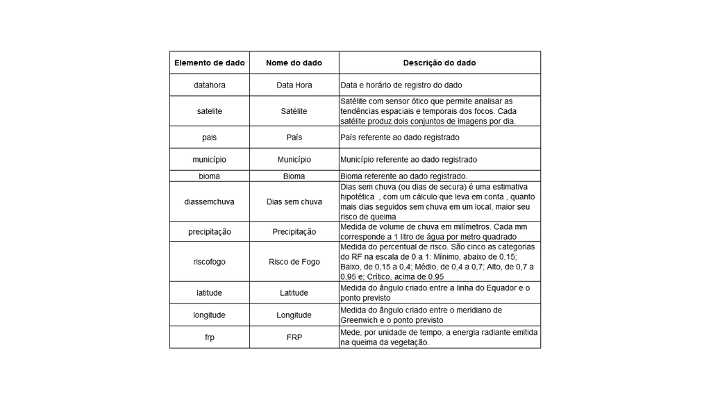

""

A análise visual do data frame indicou, de imediato, a presença de valores faltantes e de outliers, o que se confirmou na etapa seguinte do trabalho.

## **3. Análise Exploratória dos dados**

A presença de outliers e de dados faltantes nas variáveis **diassemchuva, riscofogo e precipitacao** indicou a necessidade de tratamento da base de dados amostral. Isso se confirmou com a distribuição assimétrica dos dados nos histogramas das três variáveis.

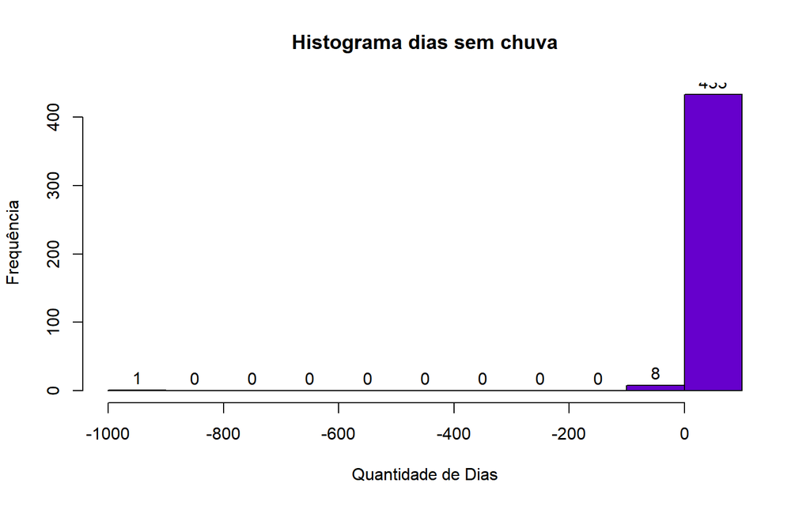

```r
hist(dados_queimadas_v1$diasemchuva,
     main = "Histograma dias sem chuva",
     xlab = "Quantidade de Dias",
     ylab = "Frequência",
     col = "#6600cc",
     labels = TRUE)
```

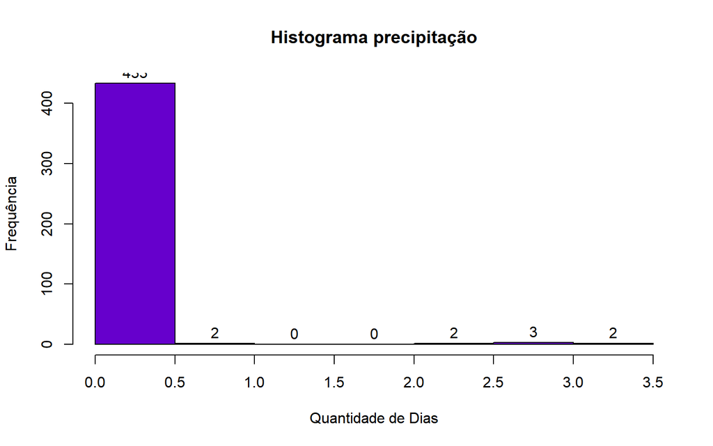

```r
hist(dados_queimadas_v1$precipitacao,
     main = "Histograma precipitação",
     xlab = "Quantidade de Dias",
     ylab = "Frequência",
     col = "#6600cc",
     labels = TRUE)
```

**Análise riscofogo**

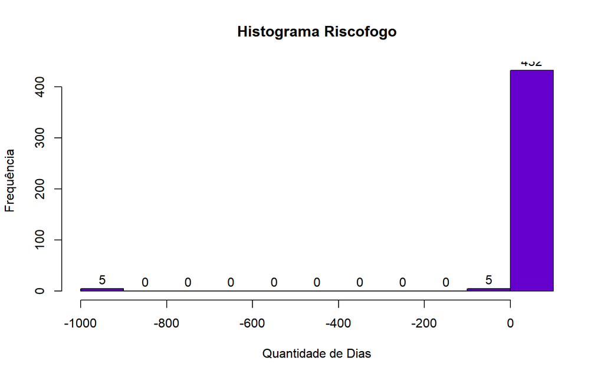

```r
hist(dados_queimadas_v1$riscofogo,
     main = "Histograma Riscofogo",
     xlab = "Quantidade de Dias",
     ylab = "Frequência",
     col = "#6600cc",
     labels = TRUE)
```

De forma complementar, a função boxplot() ou diagrama de caixa permite visualizar - tendo em vista a descrição dos quartis, da mediana e outliers - a dispersão e os valores discrepantes, contribuindo para o diagnóstico da distribuição assimétrica dos dados.

```r
boxplot(dados_queimadas_v1$diasemchuva)
```

```r
boxplot(dados_queimadas_v1$riscofogo)
```

O histograma e o diagrama de caixas permitiram a identificação visual do problema dos valores discrepantes.

Dessa forma, foi aplicada a função filter() para filtrar valores maiores ou iguais a zero, permitindo corrigir a distorção provocada pelos outliers nas variáveis **diasemchuva** e **riscofogo**.

```r
dados_queimadas_v2 =filter(dados_queimadas_v1, diasemchuva >=0 | is.na(diasemchuva),riscofogo >=0 | is.na(riscofogo))
```

Dados estatísticos após aplicação de filtro, que afeta os valores mínimos, uma vez que foram retirados os valores menores que zero.

```r
summary(dados_queimadas_v2)
```

```
##    datahora           satelite             pais              estado
##  Length:621         Length:621         Length:621         Length:621
##  Class :character   Class :character   Class :character   Class :character
##  Mode  :character   Mode  :character   Mode  :character   Mode  :character
##
##
##
##
##   municipio            bioma            diasemchuva     precipitacao
##  Length:621         Length:621         Min.   : 0.00   Min.   :0.00000
##  Class :character   Class :character   1st Qu.:14.00   1st Qu.:0.00000
##  Mode  :character   Mode  :character   Median :24.00   Median :0.00000
##                                        Mean   :24.27   Mean   :0.06193
##                                        3rd Qu.:37.00   3rd Qu.:0.00000
##                                        Max.   :59.00   Max.   :3.20000
##                                        NA's   :185     NA's   :185
##    riscofogo         latitude         longitude           frp
##  Min.   :0.0000   Min.   :-25.865   Min.   :-72.32   Min.   :   4.60
##  1st Qu.:0.8000   1st Qu.:-14.645   1st Qu.:-54.00   1st Qu.:  14.50
##  Median :1.0000   Median :-11.721   Median :-49.77   Median :  24.30
##  Mean   :0.8782   Mean   :-12.241   Mean   :-50.30   Mean   :  75.34
##  3rd Qu.:1.0000   3rd Qu.: -9.568   3rd Qu.:-46.94   3rd Qu.:  55.00
##  Max.   :1.0000   Max.   :  3.875   Max.   :-35.59   Max.   :5013.60
##  NA's   :185
```

```r
view(dados_queimadas_v1)
```

```r
view(dados_queimadas_v2)
```

**Análise dias sem chuva**

O comparativo do histograma da variável **diassemchuva** antes e depois do filtro, permite perceber que, sem a presença de outlier, os dados ficam melhor distribuídos.

```r
hist(dados_queimadas_v1$diasemchuva)
```

```r
hist(dados_queimadas_v2$diasemchuva)
```

```r
par(mfrow=c(1,2))
```

```r
hist(dados_queimadas_v1$diasemchuva)
```

```r
hist(dados_queimadas_v2$diasemchuva)
```

```r
par(mfrow=c(1,1))
```

```r
split.screen(figs=c(1,2))
```

```
## [1] 1 2
```

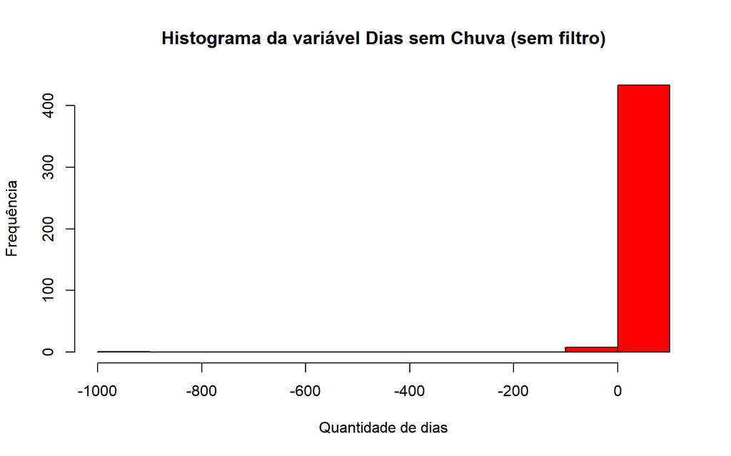

```r
hist(dados_queimadas_v1$diasemchuva,
     main = "Histograma da variável Dias sem Chuva (sem filtro)",
     xlab = "Quantidade de dias",
     ylab = "Frequência",
     col = 'red')
```

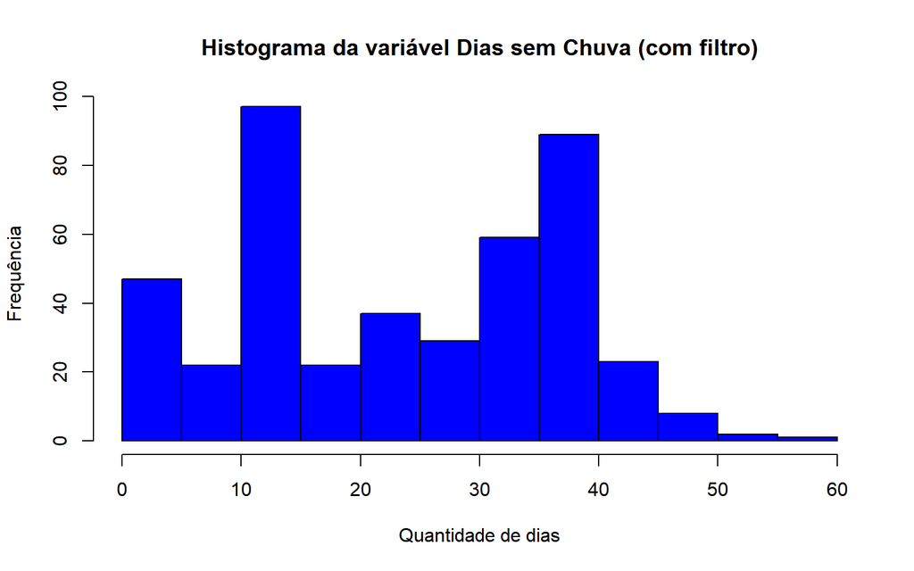

```r
hist(dados_queimadas_v2$diasemchuva,
     main = "Histograma da variável Dias sem Chuva (com filtro)",
     xlab = "Quantidade de dias",
     ylab = "Frequência",
     col = 'blue')
```

De forma complementar, a função boxplot() - ou diagrama de caixa - permite - tendo em vista a descrição dos quartis, da mediana e outliers - a dispersão e os valores discrepantes, contribuindo para o diagnóstico da distribuição assimétrica dos dados.

```r
boxplot(dados_queimadas_v1$diasemchuva)
```

```r
boxplot(dados_queimadas_v2$diasemchuva)
```

```r
par(mfrow=c(1,2))
```

```r
boxplot(dados_queimadas_v1$diasemchuva)
```

```r
boxplot(dados_queimadas_v2$diasemchuva)
```

```r
par(mfrow=c(1,1))
```

```r
boxplot(dados_queimadas_v1$diasemchuva)
```

```r
boxplot(dados_queimadas_v2$diasemchuva)
```

```r
par(mfrow=c(1,1))
```

```r
split.screen(figs=c(1,2))
```

```
## [1] 3 4
```

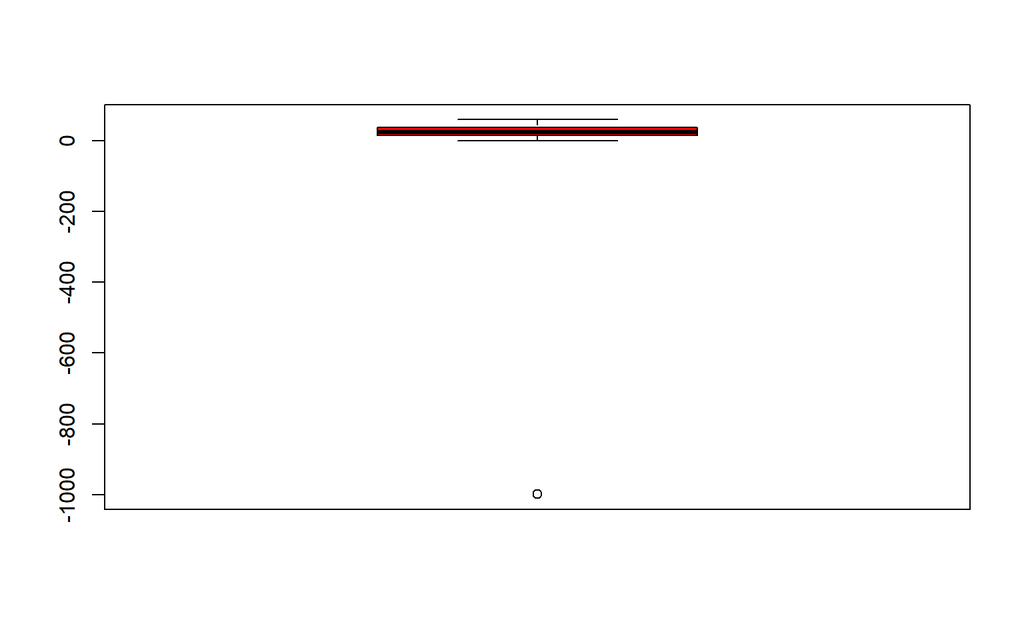

```r
boxplot(dados_queimadas_v1$diasemchuva, col = 'red')
```

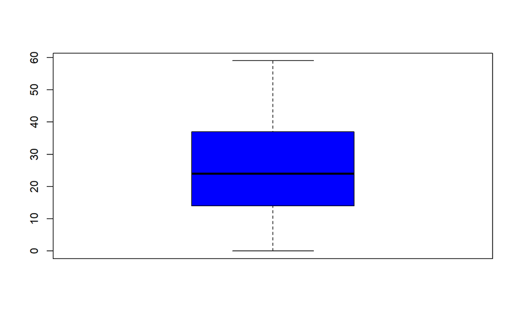

```r
boxplot(dados_queimadas_v2$diasemchuva, col = 'blue')
```

De forma complementar, a função boxplot() - ou diagrama de caixa - permite - tendo em vista a descrição dos quartis, da mediana e outliers - a dispersão e os valores discrepantes, contribuindo para o diagnóstico da distribuição assimétrica dos dados. No caso da variável **riscofogo**, percebe-se a concentração de valores próximos ao valor máximo, bem como ainda se verifica a presença de valores discrepantes.

**Diagrama de caixa da variável risco de fogo antes e depois da aplicação do filtro**

```r
boxplot(dados_queimadas_v1$riscofogo)
```

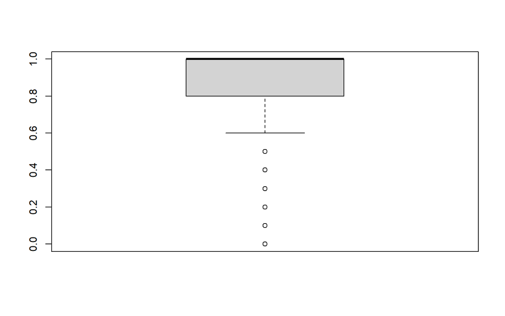

```r
boxplot(dados_queimadas_v2$riscofogo)
```

```r
par(mfrow=c(1,2))
```

```r
boxplot(dados_queimadas_v1$riscofogo)
```

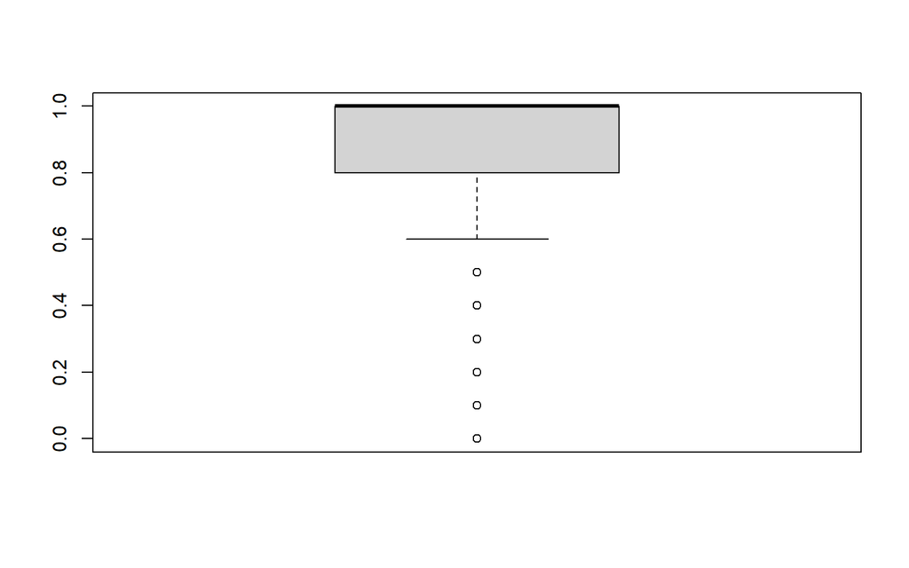

```r
boxplot(dados_queimadas_v2$riscofogo)
```

```r
par(mfrow=c(1,1))
```

```r
split.screen(figs=c(1,2))
```

```
## [1] 5 6
```

```r
boxplot(dados_queimadas_v1$riscofogo, col = 'red')
```

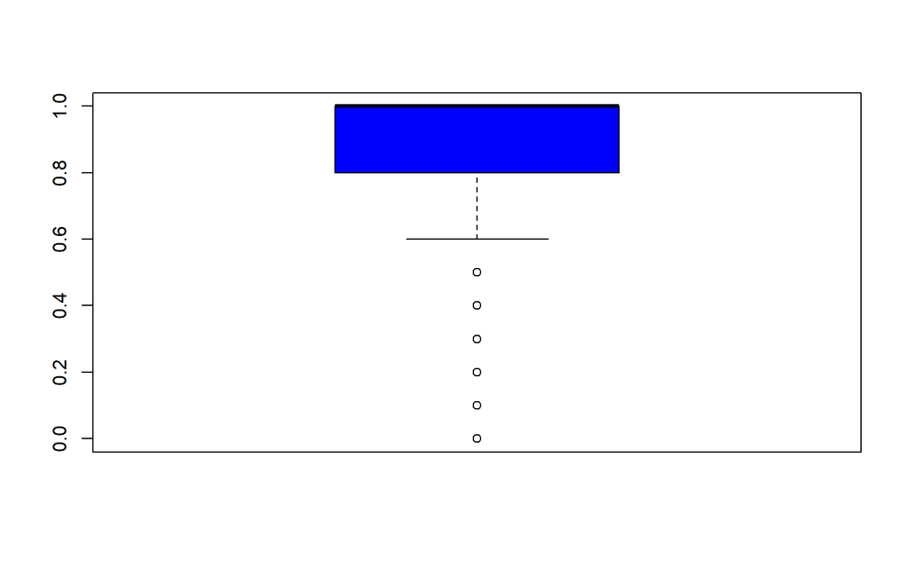

```r
boxplot(dados_queimadas_v2$riscofogo, col = 'blue')
```

Após a remoção dos outliers, foi realizada a contagem dos valores NA, Encontrados em três variáveis, **diasemchuva, precipitacao e riscofogo**, os valores faltantes correspondem a 185 linhas, num total de 555. Se consideradas as 12 variáveis, um total de 2.220 informações são afetadas.

```r
sapply(dados_queimadas_v2, function(x)sum(is.na(x)))
```

```
##     datahora     satelite         pais       estado    municipio        bioma
##            0            0            0            0            0            0
##  diasemchuva precipitacao    riscofogo     latitude    longitude          frp
##          185          185          185            0            0            0
```

```r
sum(is.na(dados_queimadas_v2)) %>%
  kable()
```

| x |
| --- |
| 555 |

## **Aplicando Imputação em Valores Missing Usando Método PMM (Predictive Mean Matching)**

A imputação dos dados faltantes foi realizada a partir do método Predictive Mean Matching (PMM). Esse procedimento atribui valores às posições afetadas pela ocorrência de NA por uma estimativa que busca manter a distribuição verificada na amostra.

1º O primeiro passo foi encontrar as variáveis com dados do tipo caracter e pegar o nome das colunas.

````
```r
chr_col <- as.integer(0)
chrnames <- names(Filter(is.character, dados_queimadas_v2))
chrnames
```

```
## [1] "datahora"  "satelite"  "pais"      "estado"    "municipio" "bioma"
```

```r
k = 1
```
````

2º Depois, foi identificado o índice dessas colunas

````
```r
for(i in chrnames){
  while (k <= 6){ #nesse dataset temos apenas 6
grep(i, colnames(dados_queimadas_v2))
chr_col[k] <- grep(i, colnames(dados_queimadas_v2))
k = k + 1
break
  }
}
```
````

A variável atribuída **chr_col** retorna as colunas cujos dados são do tipo caracter.

```r
chr_col
```

```
## [1] 1 2 3 4 5 6
```

Definindo a regra de imputação: o m é o número de imputações a serem feitas; maxit é o número de iterações; e meth é o método aplicado (sabe-se que, no pacote Mice, o método default é o PMM)

```r
regra_imputacao <- mice((dados_queimadas_v2[,-c(chr_col)]),
                        m = 1,
                        maxit = 50,
                        meth = 'pmm',)
```

Por fim, é aplicada a regra de imputação a partir da variável total_dataI. A visualização e o somatório de ocorrência de NA retornam 0, o que significa que os valores faltantes foram preenchidos. Como não foi aplicada a função set.seed, a cada vez que rodar o método, os valores gerados serão diferentes, aleatórios.

```r
total_data <- complete(regra_imputacao, 1)
View(total_data)
sum(is.na(total_data))
```

```
## [1] 0
```

Após a imputação, as variáveis categóricas foram juntadas, novamente, ao dataset por meio da função cbind()

```r
dados_queimadas_v2_final <- cbind(dados_queimadas_v2[,c(chr_col)],total_data)
View(dados_queimadas_v2_final)
View(dados_queimadas_v2)
sum(is.na(dados_queimadas_v2_final))
```

```
## [1] 0
```

```r
summary(dados_queimadas_v2_final)
```

```
##    datahora           satelite             pais              estado
##  Length:621         Length:621         Length:621         Length:621
##  Class :character   Class :character   Class :character   Class :character
##  Mode  :character   Mode  :character   Mode  :character   Mode  :character
##
##
##
##   municipio            bioma            diasemchuva     precipitacao
##  Length:621         Length:621         Min.   : 0.00   Min.   :0.00000
##  Class :character   Class :character   1st Qu.:15.00   1st Qu.:0.00000
##  Mode  :character   Mode  :character   Median :26.00   Median :0.00000
##                                        Mean   :24.65   Mean   :0.06473
##                                        3rd Qu.:38.00   3rd Qu.:0.00000
##                                        Max.   :59.00   Max.   :3.20000
##    riscofogo         latitude         longitude           frp
##  Min.   :0.0000   Min.   :-25.865   Min.   :-72.32   Min.   :   4.60
##  1st Qu.:0.8000   1st Qu.:-14.645   1st Qu.:-54.00   1st Qu.:  14.50
##  Median :1.0000   Median :-11.721   Median :-49.77   Median :  24.30
##  Mean   :0.8647   Mean   :-12.241   Mean   :-50.30   Mean   :  75.34
##  3rd Qu.:1.0000   3rd Qu.: -9.568   3rd Qu.:-46.94   3rd Qu.:  55.00
##  Max.   :1.0000   Max.   :  3.875   Max.   :-35.59   Max.   :5013.60
```

A aplicação da função summary() nos dada frames dados_queimadas_v2 (com filtro e sem imputação) e dados_queimadas_v2_final (com filtro e com a imputação) permite verificar que não houve alteração sensível no comportamento das variáveis.

Comparativo do histograma da variável **diassemchuva** em três momentos da manipulação dos dados: (a) para o data frame original, (b) para o data frame após a aplicação do filtro para retirada de valores negativos e (c) após a aplicação do método de importação para a estimação de valores para os NA.

```r
hist(dados_queimadas_v1$diasemchuva)
```

```r
hist(dados_queimadas_v2$diasemchuva)
```

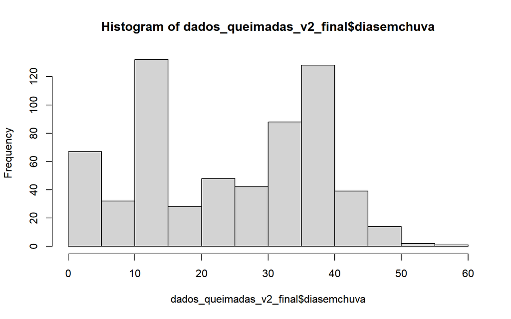

```r
hist(dados_queimadas_v2_final$diasemchuva)
```

```r
    par(mfrow=c(1,2))
```

```r
hist(dados_queimadas_v1$diasemchuva)
```

```r
hist(dados_queimadas_v2$diasemchuva)
```

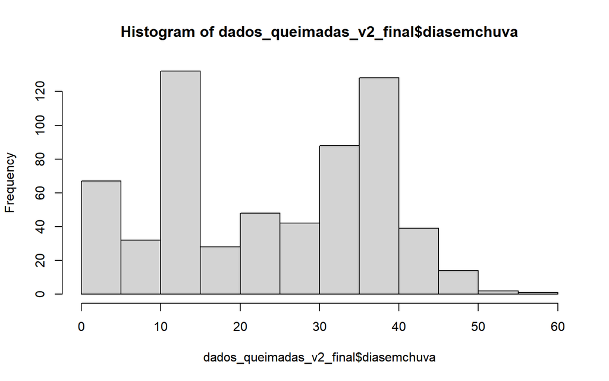

```r
hist(dados_queimadas_v2_final$diasemchuva)
```

```r
par(mfrow=c(1,1))
```

```r
split.screen(figs=c(2,2))
```

```
## [1]  7  8  9 10
```

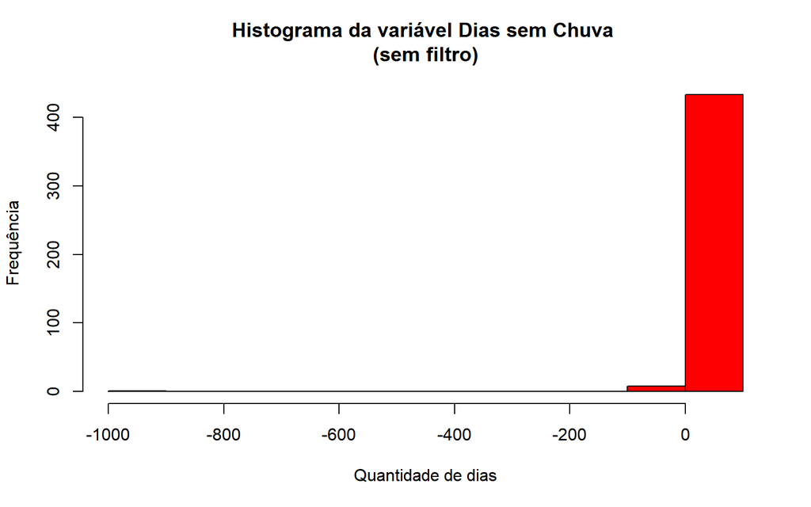

```r
hist(dados_queimadas_v1$diasemchuva,
     main = "Histograma da variável Dias sem Chuva
(sem filtro)",
     xlab = "Quantidade de dias",
     ylab = "Frequência",
     col = 'red')
```

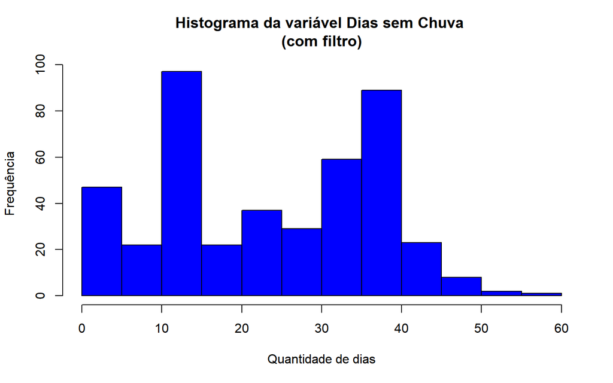

```r
hist(dados_queimadas_v2$diasemchuva,
     main = "Histograma da variável Dias sem Chuva
(com filtro)",
     xlab = "Quantidade de dias",
     ylab = "Frequência",
     col = 'blue')
```

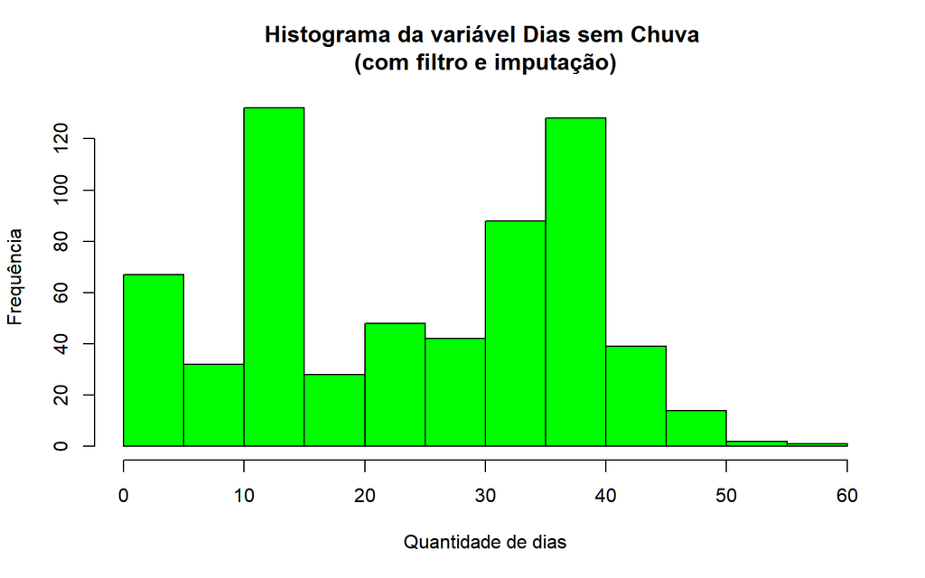

```r
hist(dados_queimadas_v2_final$diasemchuva,
     main = "Histograma da variável Dias sem Chuva
(com filtro e imputação)",
     xlab = "Quantidade de dias",
     ylab = "Frequência",
     col = 'green')
```

Comparativo do histograma da variável **riscofogo** em três momentos da manipulação dos dados: (a) para o data frame original, (b) para o data frame após a aplicação do filtro para retirada de valores negativos e (c) após a aplicação do método de importação para a estimação de valores para os NA.

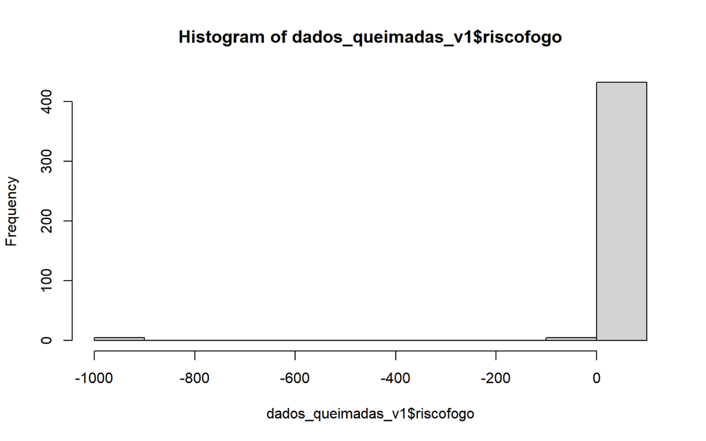

```r
hist(dados_queimadas_v1$riscofogo)
```

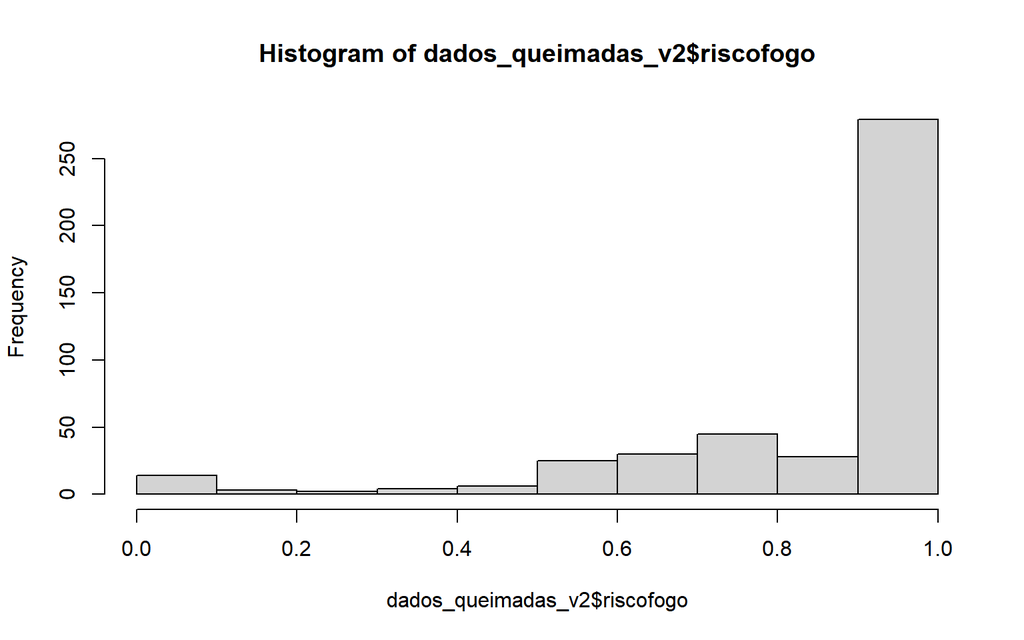

```r
hist(dados_queimadas_v2$riscofogo)
```

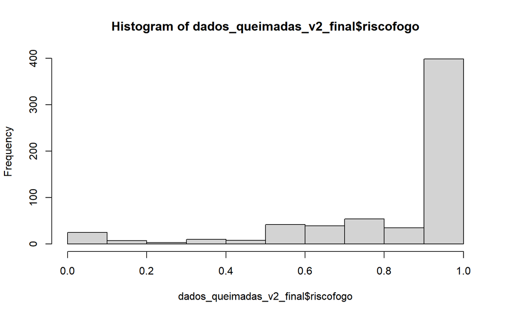

```r
hist(dados_queimadas_v2_final$riscofogo)
```

```r
par(mfrow=c(1,2))
```

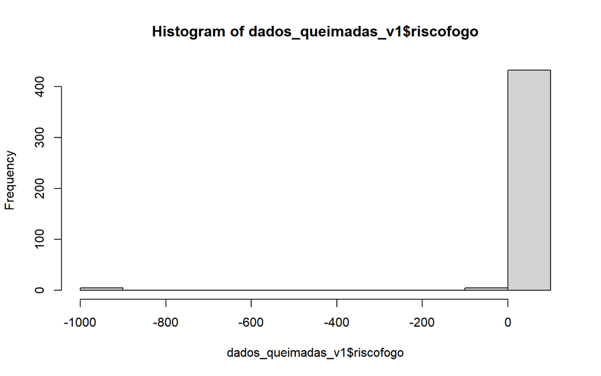

```r
hist(dados_queimadas_v1$riscofogo)
```

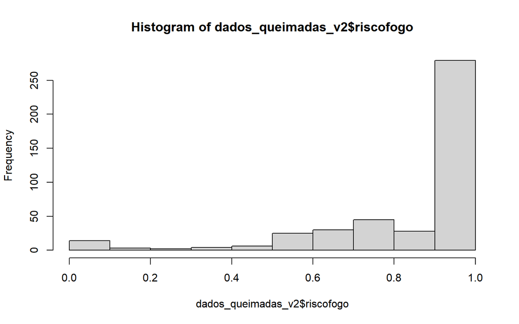

```r
hist(dados_queimadas_v2$riscofogo)
```

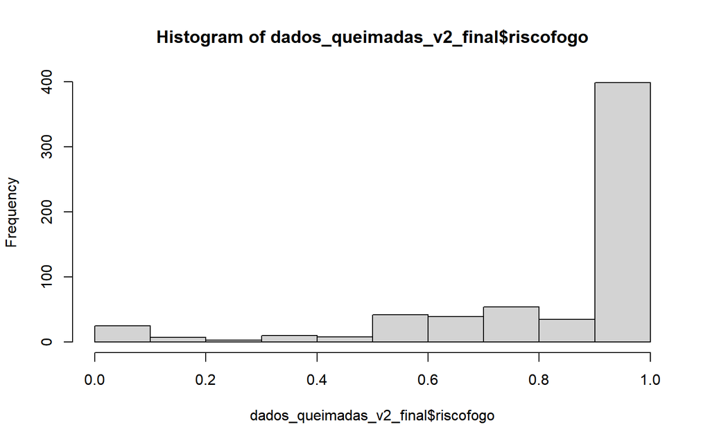

```r
hist(dados_queimadas_v2_final$riscofogo)
```

```r
par(mfrow=c(1,1))
```

```r
split.screen(figs=c(2,2))
```

```
## [1] 11 12 13 14
```

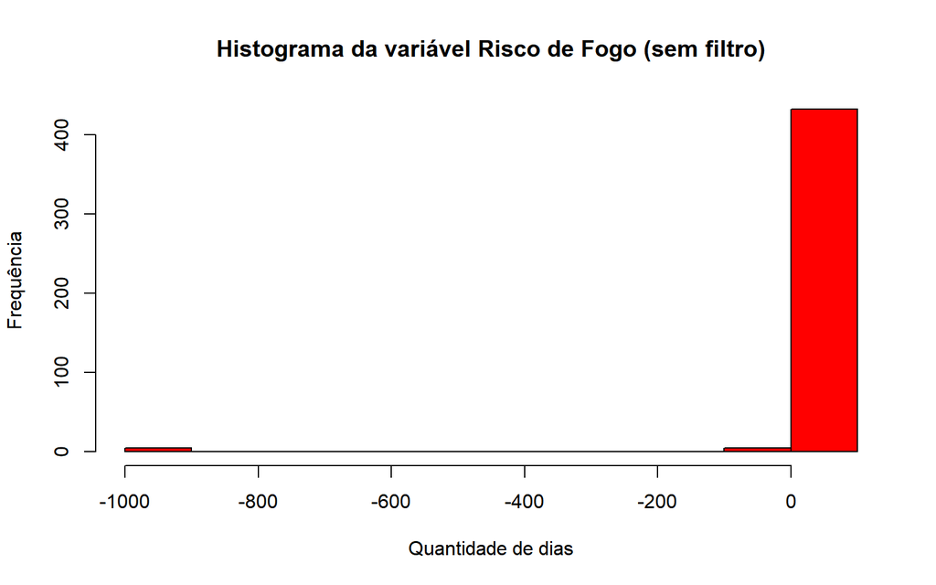

```r
hist(dados_queimadas_v1$riscofogo,
    main = "Histograma da variável Risco de Fogo (sem filtro)",
    xlab = "Quantidade de dias",
    ylab = "Frequência",
    col = 'red')
```

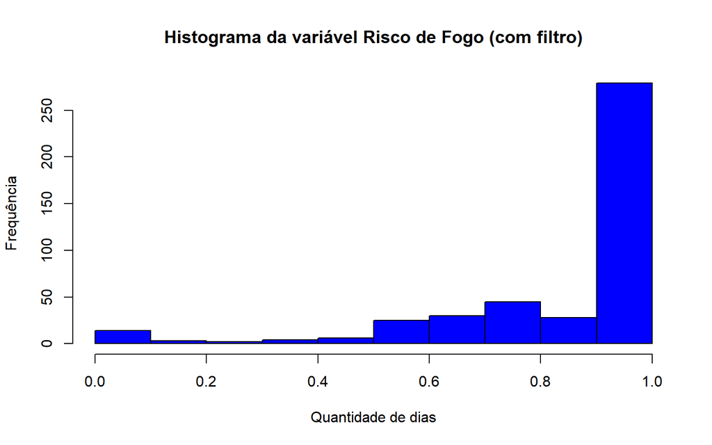

```r
hist(dados_queimadas_v2$riscofogo,
     main = "Histograma da variável Risco de Fogo (com filtro)",
     xlab = "Quantidade de dias",
     ylab = "Frequência",
     col = 'blue')
```

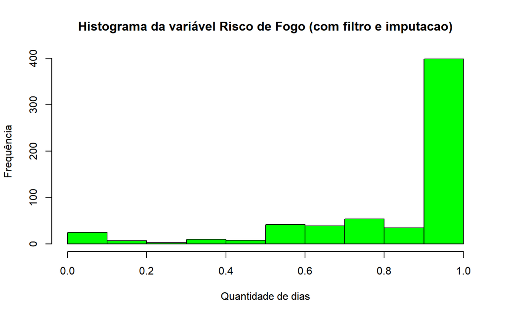

```r
hist(dados_queimadas_v2_final$riscofogo,
     main = "Histograma da variável Risco de Fogo (com filtro e imputacao)",
     xlab = "Quantidade de dias",
     ylab = "Frequência",
     col = 'green')
```

Comparativo do histograma da variável **precipitacao** em três momentos da manipulação dos dados: (a) para o data frame original, (b) para o data frame após a aplicação do filtro para retirada de valores negativos e (c) após a aplicação do método de importação para a estimação de valores para os NA. A distribuição não é impactada.

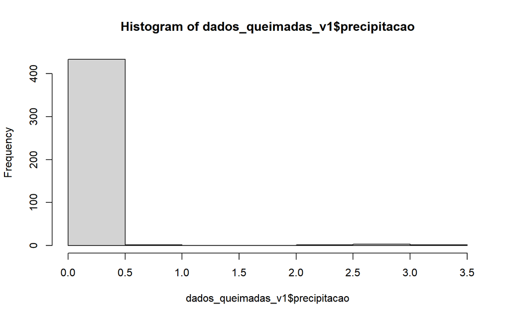

```r
hist(dados_queimadas_v1$precipitacao)
```

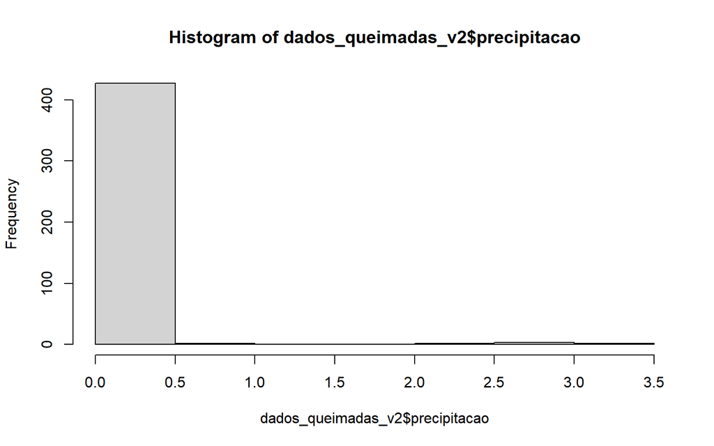

```r
hist(dados_queimadas_v2$precipitacao)
```